# Relatório Municipal de Indicadores 2023

Marapanim, Pará

SAGICAD e SNAS / MDS

# 1 ID CRAS: Indice de Desenvolvimento do CRAS

O ID CRAS é um indicador composto por três dimensões. Cada dimensão possui uma nota na qual quanto mais próxima de 5, melhor o índice e, do contrário, insatisfatório.

O Gráfico 1 mostra a evolução das médias do ID CRAS ao longo dos anos no município de Marapanim, Pará.

Gráfico 1. Evolução das médias do ID CRAS, 2014 a 2023: Marapanim, Pará

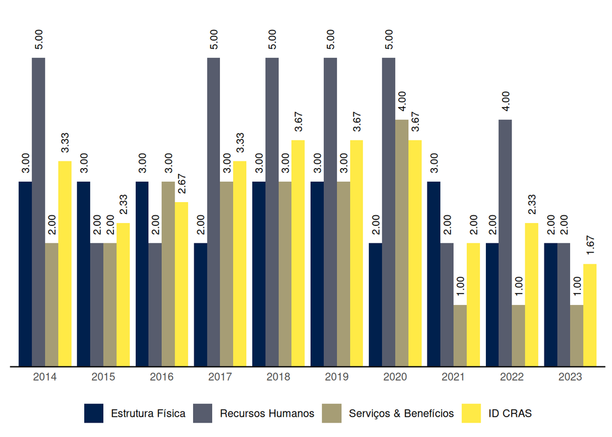

Tabela 1. Quantidade de CRAS em 2023 no município de Marapanim por capacidade de referenciamento.

Quantidade de CRAS em 2023 no município de Marapanim por capacidade de referenciamento.

| Capacidade de até: | Quantidade |
| --- | --- |
| 2.500 famílias referenciadas | 0 |
| 3.500 famílias referenciadas | 1 |
| 5.000 famílias referenciadas | 0 |

As seções a seguir apresentam os resultados do município de Marapanim em cada uma das dimensões do ID CRAS, bem como os requisitos para se alcançar os níveis superiores.

## 1.1 ID CRAS: Dimensão Estrutura Física

### 1.1.1 CRAS com capacidade de referenciamento para até 2.500 ou 3.500 famílias

Na dimensão Estrutura Física, o nível de ID do CRAS com capacidade de referenciamento para até 2.500 ou 3.500 famílias no município de Marapanim é 2.

O CRAS de **nível 2**, com capacidade de referenciamento para até 2.500 ou 3.500 famílias, na dimensão Estrutura Física:

- Possui no mínimo **2 salas de atendimento**; e
- Possui pelo menos **1 banheiro**.

Para alcançar o **nível 3** na dimensão Estrutura Física, o CRAS com capacidade de referenciamento para até 2.500 ou 3.500 famílias precisa, além dos requisitos do nível 2:

- Possuir **recepção**; e
- Possuir **acessibiliadade, ao menos parcial**.

### 1.1.2 CRAS com capacidade de referenciamento para até 5.000 famílias

Marapanim não tem CRAS com capacidade de referenciamento para até 5.000 famílias.

## 1.2 ID CRAS: Dimensão Recursos Humanos

### 1.2.1 CRAS com capacidade de referenciamento para até 2.500 famílias

Marapanim não tem CRAS com capacidade de referenciamento para até 2.500 famílias.

### 1.2.2 CRAS com capacidade de referenciamento para até 3.500 famílias

Na dimensão Recursos Humanos, o nível de ID do CRAS com capacidade de referenciamento para até 3.500 famílias no município de Marapanim é 2.

O CRAS de **nível 2**, com capacidade de referenciamento para até 3.500 famílias, na dimensão Recursos Humanos:

- Possui no mínimo **5** profissionais, sendo, pelo menos **2** com nível superior*; e
- Possui pelo menos **1 Assistente Social ou 1 Psicólogo**.

Para alcançar o **nível 3** na dimensão Recursos Humanos, o CRAS com capacidade de referenciamento para até 3.500 famílias precisa, além dos requisitos do nível 2:

- Possuir no mínimo **6** (8, se EV) profissionais, sendo pelo menos **3** (4, se EV) com nível superior; e
- Possuir no mínimo **2 Assistentes Sociais** (3, se EV).

### 1.2.3 CRAS com capacidade de referenciamento para até 5.000 famílias

Marapanim não tem CRAS com capacidade de referenciamento para até 5.000 famílias.

## 1.3 ID CRAS: Dimensão Serviços & Benefícios

Na dimensão Serviços & Benefícios, o nível de ID do CRAS no município de Marapanim é 1.

O CRAS de **nível 1** na dimensão Serviços & Benefícios em município de porte Pequeno II:

- **Não realiza** alguma(s) das seguintes atividades essenciais do PAIF: **acompanhamento de famílias, e/ou grupo/oficina com famílias, e/ou visitas domiciliares, e/ou orientação**; ou
- Possui **articulação frágil ou inexistente** com os Serviços de Educação, com os Serviços de Saúde e com os CREAS; ou
- Não possui profissionais de Serviço Social nem de Psicologia.

Para alcançar o **nível 2** na dimensão Serviços & Benefícios, o CRAS em município de porte Pequeno II precisa:

- **Executar o PAIF**, realizando no mínimo as seguintes atividades: **acompanhamento de famílias, grupo/oficina com famílias e visitas domiciliares**; e
- Possuir **forte articulação com pelo menos um dos seguintes Serviços: Serviços de Educação, Serviços de Saúde e CREAS**.

# 2 ID CREAS: Indice de Desenvolvimento do CREAS

O ID CREAS é um indicador composto por três dimensões. Cada dimensão possui uma nota na qual quanto mais próxima de 5, melhor o índice e, do contrário, insatisfatório.

O Gráfico 2 mostra a evolução das médias do ID CREAS ao longo dos anos no município de Marapanim, Pará.

Gráfico 2. Evolução das médias do ID CREAS, 2014 a 2023: Marapanim, Pará

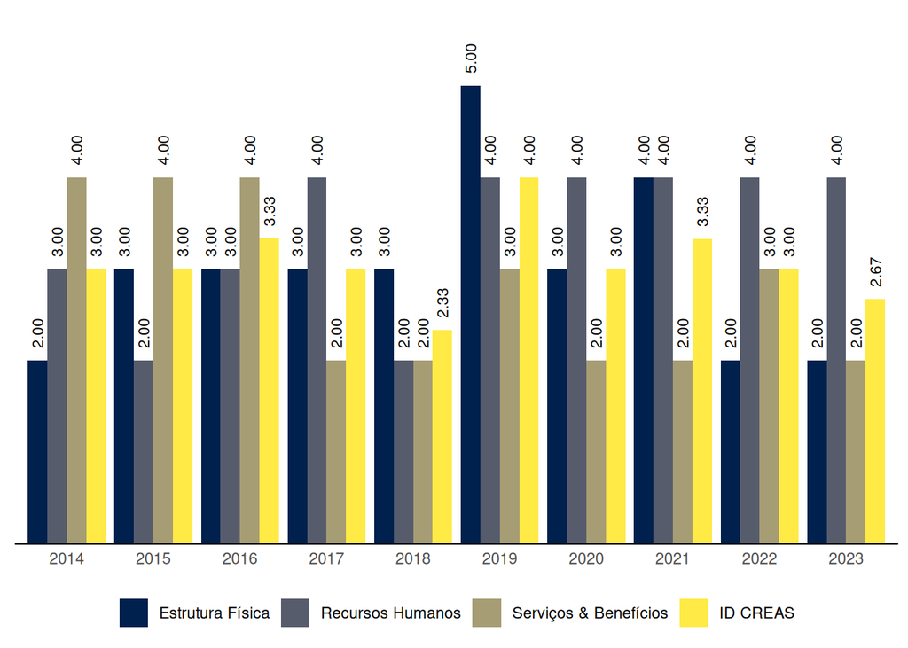

As seções a seguir apresentam os resultados do município de Marapanim em cada uma das dimensões do ID CREAS, bem como os requisitos para se alcançar os níveis superiores.

## 2.1 ID CREAS: Dimensão Estrutura Física

Na dimensão Estrutura Física, o nível de ID do CREAS no município de Marapanim é 2.

O CREAS de **nível 2** na dimensão Estrutura Física em município de porte Pequeno II:

- Possui no mínimo 3 salas (atendimento e/ou administrativa); e
- Possui no mínimo 1 banheiro.

Para alcançar o **nível 3** na dimensão Estrutura Física, o CREAS em município de porte Pequeno II precisa, além dos requisitos do nível 2:

- Possuir recepção; e
- Possuir acessibilidade, ao menos parcial.

## 2.2 ID CREAS: Dimensão Recursos Humanos

Na dimensão Recursos Humanos, o nível de ID do CREAS no município de Marapanim é 4.

O CREAS de **nível 4** na dimensão Recursos Humanos em município de porte Pequeno II:

- Possui no mínimo 1 Advogado; e
- Possui Coordenador com nível superior; e
- Tem quantidade total de trabalhadores (nível superior e médio) maior ou igual a 5 (10, se CREAS Regional), sendo no mínimo 4 (6, se CREAS Regional) deles de nível superior; e
- Possui no mínimo 1 Assistente Social e 1 Psicólogo (além disso, se for CREAS Regional, o total de Assistentes Sociais mais Psicólogos deve ser maior ou igual a 4).

Para alcançar o **nível 5** na dimensão Recursos Humanos, o CREAS em município de porte Pequeno II precisa, além dos requisitos do nível 4:

- Ter quantidade total de trabalhadores (nível superior e médio) maior ou igual a 7 (14, se CREAS Regional, sendo neste caso no mínimo 7 de nível superior); e
- Se for CREAS Regional, possuir no mínimo 2 Assistentes Sociais; e
- Se for CREAS Regional, possuir no mínimo 2 Psicólogos; e
- Possuir no mínimo 1 (2, se CREAS Regional) trabalhador de nível superior com vínculo estatutário ou empregado público celetista.

## 2.3 ID CREAS: Dimensão Serviços & Benefícios

Na dimensão Serviços & Benefícios, o nível de ID do CREAS no município de Marapanim é 2.

O CREAS de **nível 2** na dimensão Serviços & Benefícios em município de porte Pequeno II:

- Oferta o PAEFI assegurando a realização, pelo menos, das seguintes atividades: Entrevistas de acolhida para avaliação inicial dos casos, Atendimento psicossocial individual/familiar, Visitas domiciliares e Elaboração de relatórios técnicos sobre casos em acompanhamento; e
- Possui forte articulação com o CRAS.

Para alcançar o **nível 3** na dimensão Serviços & Benefícios, o CREAS em município de porte Pequeno II precisa, além dos requisitos do nível 2:

- Ofertar o PAEFI assegurando a realização da Construção de Plano Individual e/ou Familiar de atendimento (além da realização das atividades exigidas no nível 2); e
- Possuir forte articulação com o Conselho Tutelar; e
- Ofertar atendimento para variadas situações de violência ou violação de direitos e para os diferentes ciclos de vida; e
- Ofertar o Serviço de MSE (APLICA-SE SOMENTE SE O MUNICÍPIO RECEBER COFINANCIAMENTO ou se for CREAS Regional).

# 3 ID Conselho: Indice de Desenvolvimento dos Conselhos de Assistência Social

O ID Conselho é indicador desenvolvimento com o objetivo de avaliar o controle social no SUAS. Ele possui três dimensões. Cada dimensão possui uma nota na qual quanto mais próxima de 5, melhor o índice e, do contrário, insatisfatório.

O Gráfico 3 mostra a evolução das médias do ID Conselho ao longo dos anos no município de Marapanim, Pará.

Gráfico 3. Evolução das médias do ID Conselho, 2014 a 2023: Marapanim, Pará

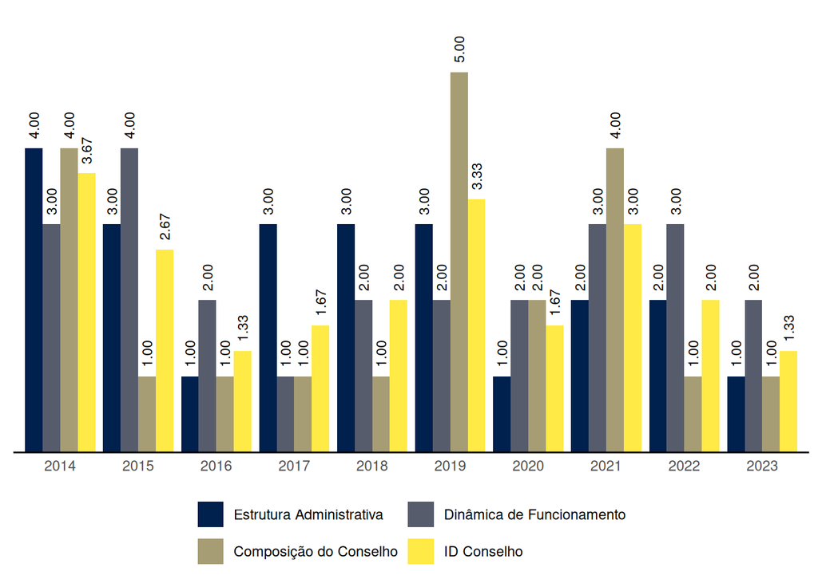

As seções a seguir apresentam os resultados do município de Marapanim em cada uma das dimensões do ID Conselho, bem como os requisitos para se alcançar os níveis superiores.

## 3.1 ID Conselho: Dimensão Estrutura Administrativa

Na dimensão Estrutura Administrativa, o nível de ID do Conselho no município de Marapanim é 1.

O Conselho de **nível 1** na dimensão Estrutura Administrativa em município de porte Pequeno II:

- **Não** possui previsão de recursos na Lei Orçamentária Anual e **não** utiliza para as despesas de seu funcionamento o mínimo de 3% do IGD; ou
- **Não** possui sala (exclusiva ou compartilhada); ou
- **Não** possui Secretaria Executiva.

Para alcançar o **nível 2** na dimensão Estrutura Administrativa, o Conselho em município de porte Pequeno II precisa:

- Possuir previsão de recursos na Lei Orçamentária Anual ou utilizar para as despesas de seu funcionamento o mínimo de 3% do IGD; e
- Possuir uma ou mais salas de uso exclusivo ou compartilhado; e
- Possuir Secretaria Executiva.

## 3.2 ID Conselho: Dimensão Dinâmica de Funcionamento

Na dimensão Dinâmica de Funcionamento, o nível de ID do Conselho no município de Marapanim é 2.

O Conselho de **nível 2** na dimensão Dinâmica de Funcionamento em município de porte Pequeno II:

- Realizou 6 ou mais reuniões plenárias no ano anterior (ordinárias e extraordinárias); e
- Deliberou sobre o Plano de Assistência Social.

Para alcançar o **nível 3** na dimensão Dinâmica de Funcionamento, o Conselho em município de porte Pequeno II precisa, além dos requisitos do nível 2:

- Possuir Regimento Interno; e
- Acompanhar o cumprimento de deliberações da Conferência Municipal.

## 3.3 ID Conselho: Dimensão Composição do Conselho

Na dimensão Composição do Conselho, o nível de ID do Conselho no município de Marapanim é 1.

O Conselho de **nível 1** na dimensão Composição do Conselho em município de porte Pequeno II:

- Possui menos de 6 conselheiros titulares; ou
- **Não** possui conselheiros titulares representantes de usuários nem de organização de usuários; ou
- **Não** possui alternância na presidência entre os representantes de governo e os representantes da sociedade civil.

Para alcançar o **nível 2** na dimensão Composição do Conselho, o Conselho em município de porte Pequeno II precisa:

- Possuir no mínimo 6 conselheiros titulares; e
- Possuir pelo menos um conselheiro titular representante de usuários ou organização de usuários; e
- Possuir alternância na presidência entre os representantes de governo e os representantes da sociedade civil.